# DM—決策樹(Decision Tree)

POLab

2017/05/19

[【回到首頁】](https://github.com/PO-LAB/Data-Mining)

本篇內容，會繼續介紹一些常用的資料探勘模型：

這裡拿網路上一個公開資料(鐵達尼號的乘客資料)來進行分析，[資料載點如下](http://www.rdatamining.com/data/titanic.raw.rdata?attredirects=0&d=1)。

# **決策樹(Decision Tree)**

無論在分類或預測上，決策樹的演算法都有很好的效果。

但它最強大的地方，莫過於樹狀分支的結構：可以明顯呈現分類的規則！與一些機器學習的方法(NN, SVM…)相比，相當容易進行解釋，以及分析規則之間的關係。

這裡就簡單用CART決策樹來練習，對應的套件是`rpart`，一樣使用上次鐵達尼號的資料：

```r
# 記得要給定資料所在的路徑(path)，例如：我把下載的資料放在C槽下：
load("C:/titanic.raw.rdata")  #匯入.rdata檔
```

```r
require(rpart)

# 先把資料區分成 train=0.8, test=0.2
set.seed(22)
train.index <- sample(x=1:nrow(titanic.raw), size=ceiling(0.8*nrow(titanic.raw) ))
train <- titanic.raw[train.index, ]
test <- titanic.raw[-train.index, ]

# CART的模型：把存活與否的變數(Survived)當作Y，剩下的變數當作X
cart.model<- rpart(Survived ~. ,
                    data=train)

# 輸出各節點的細部資訊(呈現在console視窗)
cart.model
```

```
## n= 1761
##
## node), split, n, loss, yval, (yprob)
##       * denotes terminal node
##
##  1) root 1761 558 No (0.68313458 0.31686542)
##    2) Sex=Male 1398 288 No (0.79399142 0.20600858)
##      4) Age=Adult 1348 264 No (0.80415430 0.19584570) *
##      5) Age=Child 50  24 No (0.52000000 0.48000000)
##       10) Class=3rd 37  11 No (0.70270270 0.29729730) *
##       11) Class=1st,2nd 13   0 Yes (0.00000000 1.00000000) *
##    3) Sex=Female 363  93 Yes (0.25619835 0.74380165)
##      6) Class=3rd 155  73 No (0.52903226 0.47096774) *
##      7) Class=1st,2nd,Crew 208  11 Yes (0.05288462 0.94711538) *
```

要畫出決策樹(視覺化)，雖然用平常的`plot()`就可以達成

但rpart有專屬的繪圖套件`rpart.plot`，函式是`prp()`

說真的，用`prp()`畫出來的決策樹，比較好看一些：

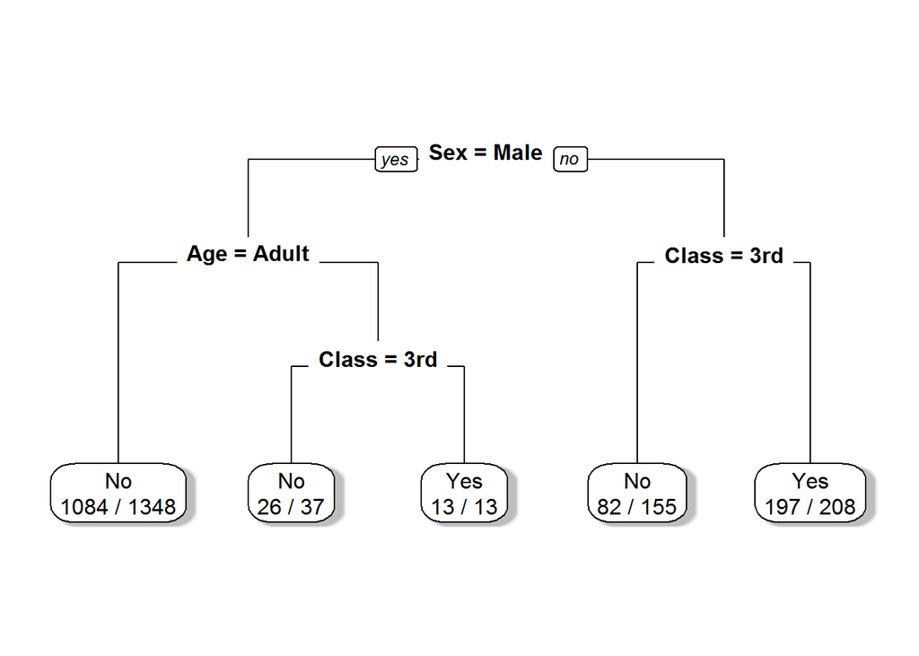

```r
require(rpart.plot)
prp(cart.model,         # 模型
    faclen=0,           # 呈現的變數不要縮寫
    fallen.leaves=TRUE, # 讓樹枝以垂直方式呈現
    shadow.col="gray",  # 最下面的節點塗上陰影
    # number of correct classifications / number of observations in that node
    extra=2)
```

(最下面節點的數字，代表：**number of correct classifications / number of observations in that node**)

根據以上決策樹，可以發現**是男生或女生**其實很重要(因為是第一個分支規則)，其次是在船上的艙位等級。

因此，我們可以這樣解釋：

```
即使是女性，可是擁有的艙位若是最低下的(3rd)，則大概有一半的死亡機率(82/155=53%)；
但當妳的艙位高人一等時，則有相當高的存活機率(197/208=95%)。
```

又或者是：

[output not shown]

以及

```
若是男性小孩，就和艙位等級有關：高級艙位的小孩全都獲救(13/13)，可是低艙位的小孩有七成機率(26/37=70%)會死。
```

**(男生好可憐)**

●也可用另一個繪圖套件`partykit`，函式是`as.party()`和`plot()`

```r
require(partykit)
rparty.tree <- as.party(cart.model) # 轉換cart決策樹
rparty.tree # 輸出各節點的細部資訊
```

```
##
## Model formula:
## Survived ~ Class + Sex + Age
##
## Fitted party:
## [1] root
## |   [2] Sex in Male
## |   |   [3] Age in Adult: No (n = 1348, err = 19.6%)
## |   |   [4] Age in Child
## |   |   |   [5] Class in 3rd: No (n = 37, err = 29.7%)
## |   |   |   [6] Class in 1st, 2nd: Yes (n = 13, err = 0.0%)
## |   [7] Sex in Female
## |   |   [8] Class in 3rd: No (n = 155, err = 47.1%)
## |   |   [9] Class in 1st, 2nd, Crew: Yes (n = 208, err = 5.3%)
##
## Number of inner nodes:    4
## Number of terminal nodes: 5
```

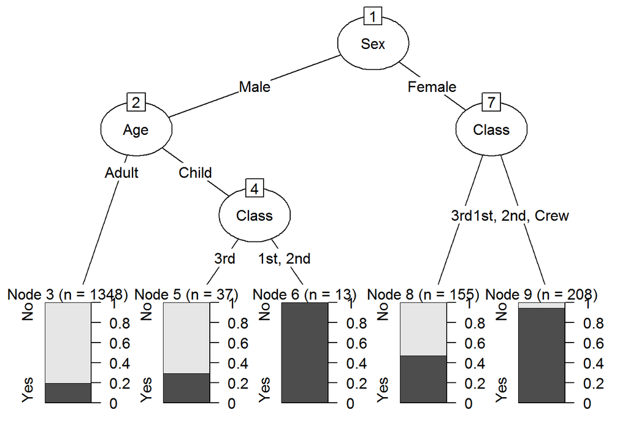

```r
plot(rparty.tree)
```

用這個套件畫出來的圖也是蠻容易一目了然的呢! 有不一樣的感覺~

有決策樹之後，就要進行預測！

還記得在線性迴歸使用過的`predict()`嗎？這時就會派上用場囉(在這裡，會同時計算預測準確率)：

```r
pred <- predict(cart.model, newdata=test, type="class")

# 用table看預測的情況
table(real=test$Survived, predict=pred)
```

```
##      predict
## real   No Yes
##   No  278   9
##   Yes  93  60
```

```r
# 計算預測準確率 = 對角線的數量/總數量
confus.matrix <- table(real=test$Survived, predict=pred)
sum(diag(confus.matrix))/sum(confus.matrix) # 對角線的數量/總數量
```

```
## [1] 0.7681818
```

結果顯示，模型在測試集中的預測能力大約77%，但模型的預測準確率還有提升的可能嗎？我們繼續對模型進行修樹~

```r
printcp(cart.model) # 先觀察未修剪的樹，CP欄位代表樹的成本複雜度參數
```

```
##
## Classification tree:
## rpart(formula = Survived ~ ., data = train)
##
## Variables actually used in tree construction:
## [1] Age   Class Sex
##
## Root node error: 558/1761 = 0.31687
##
## n= 1761
##
##         CP nsplit rel error  xerror     xstd
## 1 0.317204      0   1.00000 1.00000 0.034989
## 2 0.016129      1   0.68280 0.68280 0.030966
## 3 0.011649      2   0.66667 0.68817 0.031054
## 4 0.010000      4   0.64337 0.66487 0.030668
```

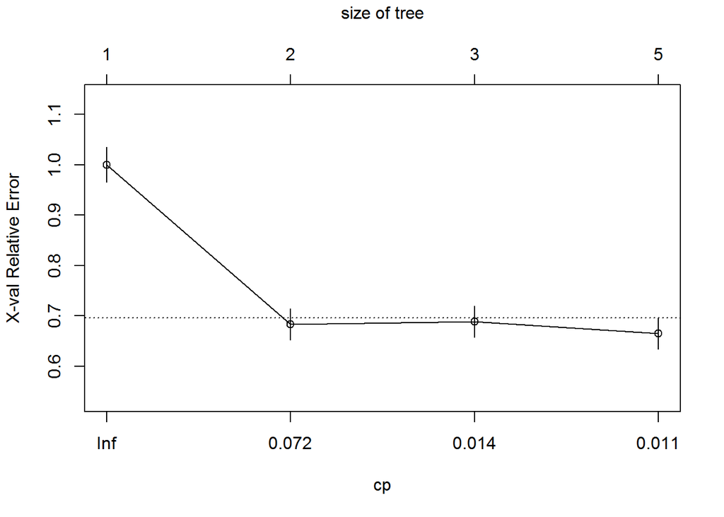

```r
plotcp(cart.model) # 畫圖觀察未修剪的樹
```

```r
prunetree_cart.model <- prune(cart.model, cp = cart.model$cptable[which.min(cart.model$cptable[,"xerror"]),"CP"]) # 利用能使決策樹具有最小誤差的CP來修剪樹
```

修剪完決策樹之後，讓我們重新建構一次預測模型

```r
prunetree_pred <- predict(prunetree_cart.model, newdata=test, type="class")

# 用table看預測的情況
table(real=test$Survived, predict=prunetree_pred)
```

```
##      predict
## real   No Yes
##   No  278   9
##   Yes  93  60
```

```r
prunetree_confus.matrix <- table(real=test$Survived, predict=prunetree_pred)
sum(diag(prunetree_confus.matrix))/sum(prunetree_confus.matrix) # 對角線的數量/總數量
```

```
## [1] 0.7681818
```

很顯然，模型的預測準確率並沒有提升，一樣是大約77%，這是因為我們在修剪時所挑選到滿足條件的CP值為**0.01**，而函式`rpart()`預設的CP值就是**0.01**，故前後模型的結果一致。

再來，我們爲了避免模型過度擬合(overfitting)，故要利用K-fold Cross-Validation的方法進行交叉驗證，我們使用`caret`這個套件，而K先設定為10次~

```r
require(caret)
require(e1071)
train_control <- trainControl(method="cv", number=10)
train_control.model <- train(Survived~., data=train, method="rpart", trControl=train_control)
train_control.model
```

```
## CART
##
## 1761 samples
##    3 predictor
##    2 classes: 'No', 'Yes'
##
## No pre-processing
## Resampling: Cross-Validated (10 fold)
## Summary of sample sizes: 1585, 1584, 1584, 1585, 1586, 1585, ...
## Resampling results across tuning parameters:
##
##   cp          Accuracy   Kappa
##   0.01164875  0.7796983  0.4045009
##   0.01612903  0.7774223  0.4055445
##   0.31720430  0.7097437  0.1417312
##
## Accuracy was used to select the optimal model using  the largest value.
## The final value used for the model was cp = 0.01164875.
```

然而，我們一開始修剪樹之後所得到的決策樹模型，最佳的預測準確率大約為77%，而現在再透過交叉驗證所Tune得的參數，使得模型的最佳預測準確率大約提升為78%。

# **總結**

在資料探勘領域中，決策樹(Decision Tree)是相當常見的方法，例如在醫學研究上，對某種特定的疾病(糖尿病，代謝症候群等)找出可以前期篩檢分類，或是預測的因子時，就常以決策樹的方法來進行，而決策樹較爲不同之處在於可用圖像化來呈現結果，即使不了解背後理論，仍可解讀並判斷。

進行決策樹分析要注意的是，當樣本存在類別不不衡的問題時，決策樹對於小類的樣本根本無能為力，模型的效能會大打折扣。